# Homework #5

Cory Roth

3/06/2023

## Chocolate

1. What is the overall number of chocolate bars rated?

   ```r
   library(ggplot2)
   choco <- read.csv("https://ds202-at-isu.github.io/labs/data/choco.csv")
   #head(choco)

   str(choco)
   ```

   ```
   ## 'data.frame':    1852 obs. of  9 variables:
   ##  $ Company             : chr  "A. Morin" "A. Morin" "A. Morin" "A. Morin" ...
   ##  $ Specific.Bean.Origin: chr  "Agua Grande" "Kpime" "Panama" "Madagascar" ...
   ##  $ REF                 : int  1876 1676 1011 1011 1011 1011 1015 1015 1015 1015 ...
   ##  $ Review.Date         : int  2016 2015 2013 2013 2013 2013 2013 2013 2013 2013 ...
   ##  $ Cocoa.Pct           : num  63 70 70 70 70 70 70 70 70 70 ...
   ##  $ Company.Location    : chr  "France" "France" "France" "France" ...
   ##  $ Rating              : num  3.75 2.75 2.75 3 3.25 3.75 2.75 3 3.25 4 ...
   ##  $ Bean.Type           : chr  "" "" "" "Criollo" ...
   ##  $ Broad.Bean.Origin   : chr  "Sao Tome" "Togo" "Panama" "Madagascar" ...
   ```

   There was 1852 chochlate bars rated
2. How does the number of ratings depend on the year? Draw a bar chart of the number of reports.

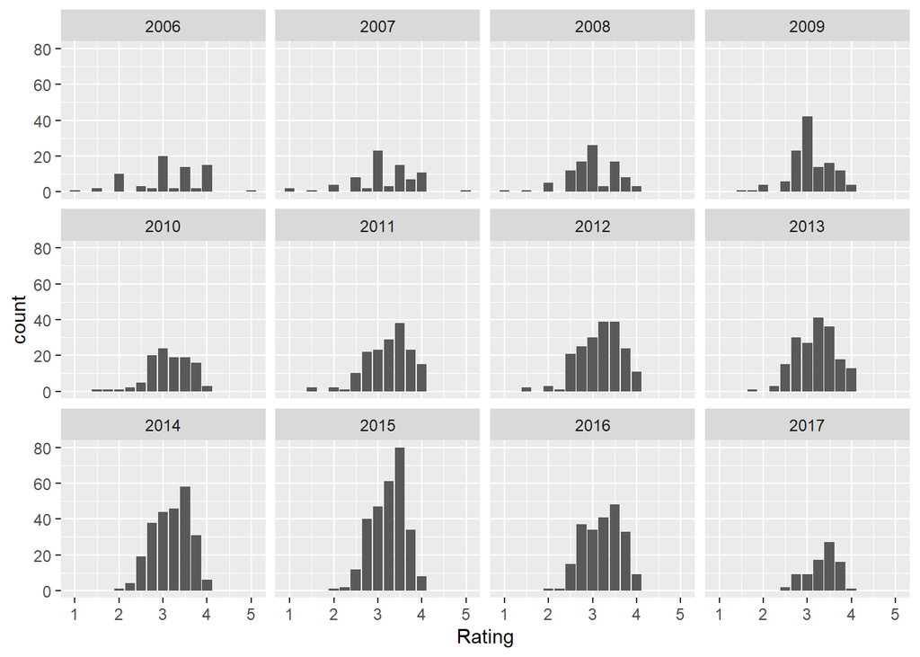

   ```r
   ggplot(choco, aes(Rating))+
     geom_bar()+
     facet_wrap(.~Review.Date)
   ```

3. For each of the questions below provide at least one graphic as a basis for your answer.
   1. How are ratings distributed? Draw a histogram of ratings and describe it. Don’t forget to mention outliers, if there are any.

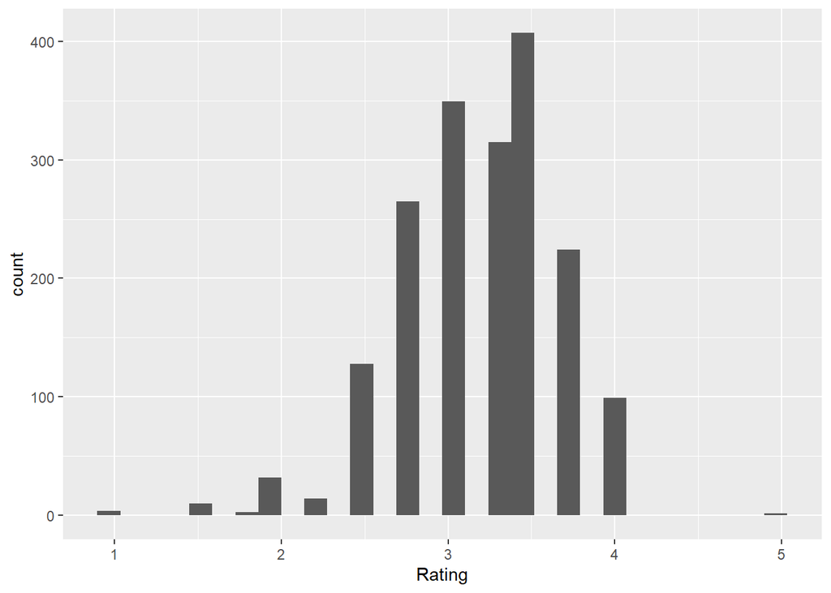

```r
ggplot(choco, aes(Rating))+
  geom_histogram()
```

The Ratings are on a 5 points scale. Most Ratings are between 2.5-4. There are very few ratings that a perfect 5 and very few that are the worst score being a 1

```
2.  Do ratings depend on the cocoa percentage of a chocolate bar?
```

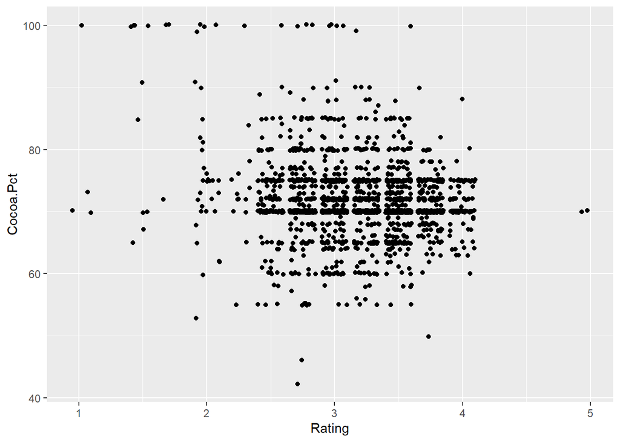

```r
ggplot(choco, aes(Rating, Cocoa.Pct))+
  geom_jitter()
```

There does not seem to be a correlation between cocoa percentage and ratings. Looking at the graph above, the ratings are not depeneanded on cocoa.Pct 3. How do ratings compare across different company locations? Focus on the three locations with the most ratings:

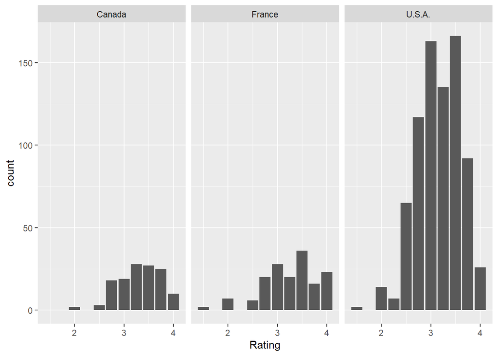

```r
 top3 <- dplyr::filter(choco, Company.Location %in% c("U.S.A.", "France", "Canada"))
ggplot(top3, aes(Rating))+
  geom_bar()+
  facet_wrap(.~Company.Location)
```

Canada’s and France’s Average Rating is between 3-4, whereas the USA has a lot more chocolate bars under the 3 rating, meaning the USA overall rating would be lower than Canada and France

```
    top3 <- dplyr::filter(choco, Company.Location %in% c("U.S.A.", "France", "Canada"))
```

Upload your answers to the repository. Discuss and refine answers as a team.

YOUR OWN QUESTION? 2. How does the number of ratings depend on the Company in France?

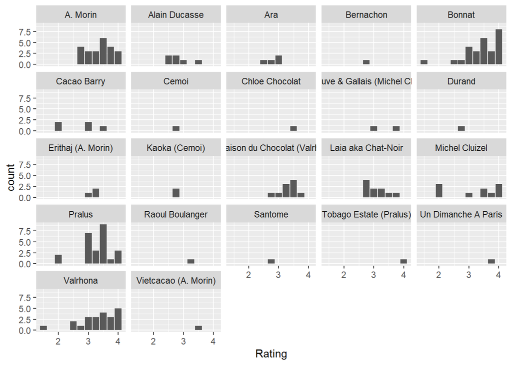

```r
 topF <- dplyr::filter(choco, Company.Location %in% c( "France"))

 ggplot(topF, aes(Rating))+
      geom_bar()+
  facet_wrap(.~Company)
```